# DPWH Budget Analysis

## 7.3 Appropriations Committee Chairs' Home Districts

The chair writes the committee report. Davao City recurs here too - Ungab and Nograles, successive chairs, both represented it - as do the provincial ties of the party-list chairs who followed.

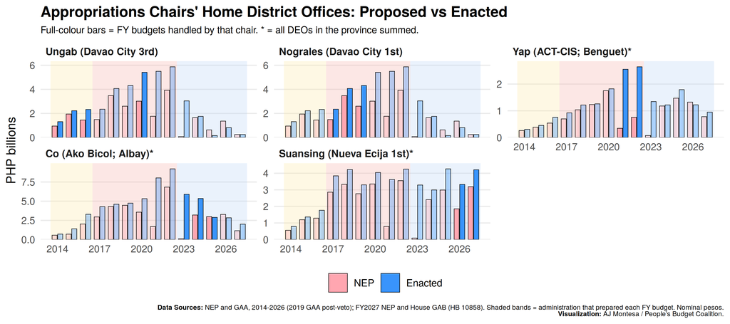

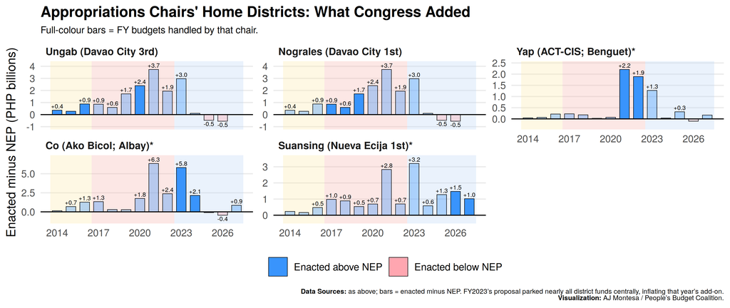

## 7.4 In Office Versus Out: The Summary

Averaging across the window makes the contrast plain. For each President and Speaker, the table compares the mean enacted budget of their home district offices, and the mean congressional add-on, in the years they held power against the years they did not.

Mean home-district DEO budget and congressional add-on (PHP billions), in-office vs out, FY2014-2026.

| Role | Official (home area) | Enacted, in office | Enacted, out | Add-on, in office | Add-on, out |
| --- | --- | --- | --- | --- | --- |
| President | Aquino (Tarlac) | 1.81 | 4.01 | 0.28 | 1.52 |
|  | Duterte (Davao City) | 4.59 | 1.66 | 1.88 | 0.51 |
|  | Marcos (Ilocos Norte) | 6.20 | 2.32 | 2.36 | 0.55 |
| Speaker | Belmonte (QC 4th)* | 2.43 | 4.88 | 1.12 | 1.67 |
|  | Alvarez (Davao del Norte 1st) | 0.94 | 1.05 | 0.10 | 0.15 |
|  | Arroyo (Pampanga 2nd) | 1.51 | 1.13 | 0.71 | 0.48 |
|  | Cayetano (Taguig-Pateros)* | 8.00 | 6.15 | 3.31 | 2.11 |
|  | Velasco (Marinduque) | 1.97 | 0.80 | 1.22 | 0.28 |
|  | Romualdez (Leyte 1st) | 2.40 | 0.80 | 1.49 | 0.25 |
|  | Dy (Isabela 6th)* | 5.43 | 4.13 | 2.81 | 1.84 |

The pattern holds for most officials but not all, and the exceptions matter. Among the three presidents, Duterte's and Marcos's home districts drew both larger enacted budgets and larger net additions while they were in power; Aquino's Tarlac did not. Among the seven Speakers, five home districts did better in office, but two did not: Belmonte's Quezon City offices averaged ₱2.43B in office against ₱4.88B out, and Alvarez's Davao del Norte ₱0.94B against ₱1.05B. This is a correlation, not a verdict. Home provinces differ in size, need, number of district offices, and absorptive capacity, and a larger home-district budget can follow from any of these. What the table supports is narrow: the DPWH offices in officials' home areas are often, though not always, funded more generously. That is a reason to read the district-level numbers above and the House FY 2027 jumps (Ilocos Norte, the Speaker's Isabela, the chair's Nueva Ecija) more closely, not a finding that any increase was improper.

# 8 The Line-Item Vetoes: 2019 and 2025

Twice in this window the President reached past Congress's realignments and struck enacted amounts out of the DPWH budget by **line-item veto** - in **FY2019 (₱95.4B)** and again in **FY2025 (₱26.1B)**. In both years the pattern was the same: Congress inflated the proposal (heavily in 2019's Local Program, and in 2025's Convergence and Flood programs), and the President then vetoed a large block of it, almost all from the **Central Office**. The enacted GAA used throughout this report is the **post-veto** figure in both years.

## 8.1 The 2019 Veto (₱95.4B)

In FY2019, Congress raised the DPWH's New Appropriations only modestly in aggregate (from a **₱544.5B** proposal to a **₱549.4B** legislated total) but **heavily reallocated** the money - above all into the Local Program. The President then exercised **line-item vetoes totaling ₱95.37B**, almost all of it from that program, bringing the enacted GAA down to **₱454.0B** (the NEP-to-GAA dip visible back in Section 3). The three stages below are what the President **proposed** (NEP), what Congress **legislated** (the pre-veto total), and what was finally **enacted** after the line-item veto.

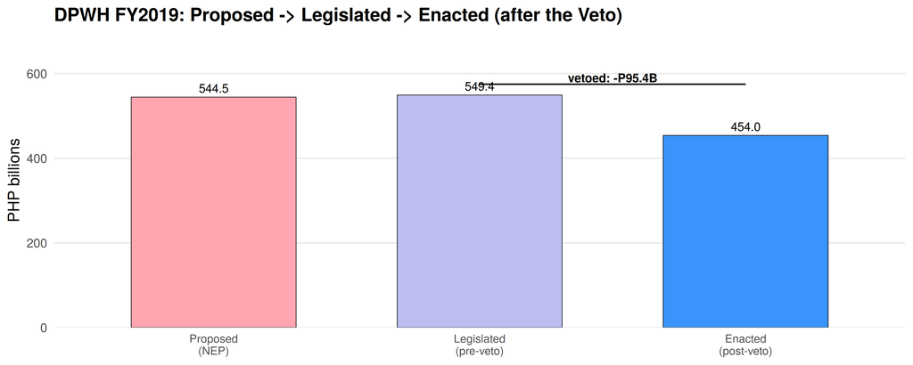

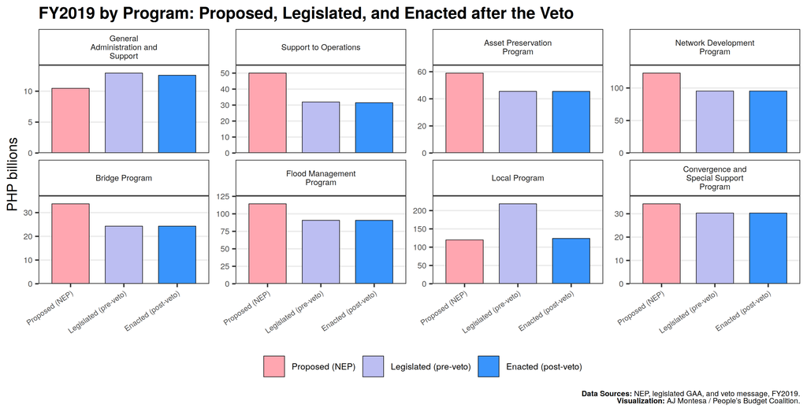

The veto was overwhelmingly a **Local Program** event: only that program (plus token amounts in the two overhead lines) shows a legislated (pre-veto) bar towering over the enacted level. Breaking the vetoed line items down by **type of work** and by **engineering office** shows where the realigned money had been parked:

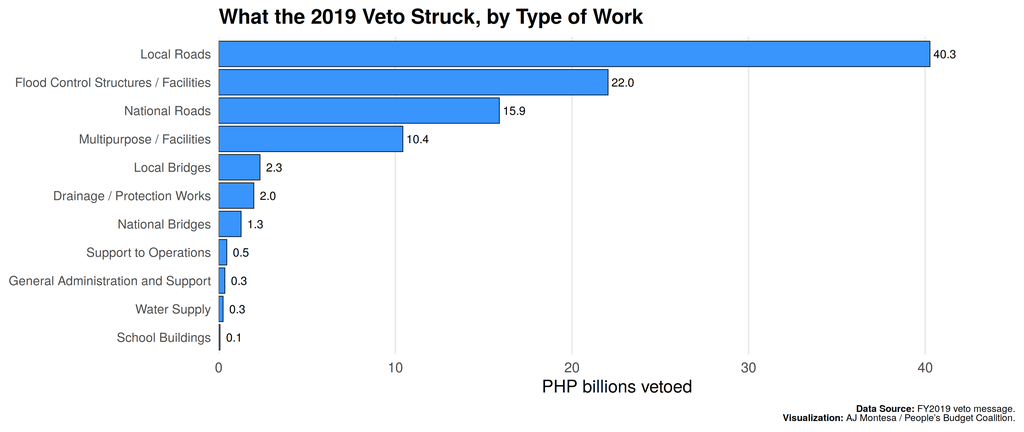

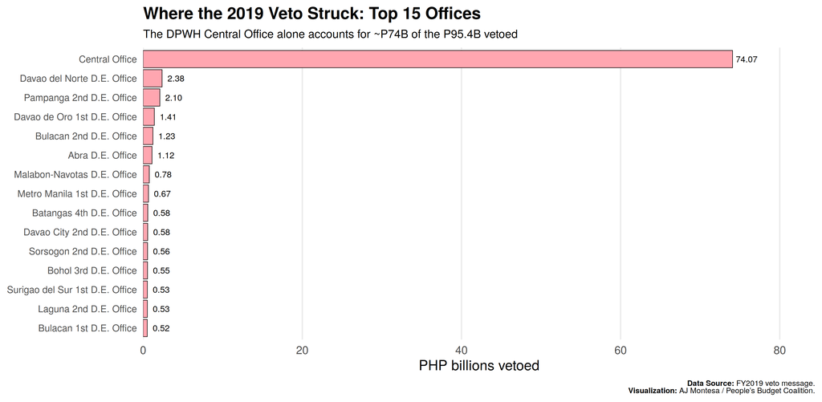

FY2019 DPWH: proposed, legislated (pre-veto), vetoed, and enacted (post-veto) --- PHP billions

| Program | Proposed (NEP) | Legislated (pre-veto) | Vetoed | Enacted (post-veto) |
| --- | --- | --- | --- | --- |
| General Administration and Support | 10.5 | 12.9 | 0.3 | 12.6 |
| Support to Operations | 50.0 | 31.9 | 0.5 | 31.5 |
| Asset Preservation Program | 59.0 | 45.5 | 0.0 | 45.5 |
| Network Development Program | 122.9 | 95.3 | 0.0 | 95.3 |
| Bridge Program | 33.7 | 24.3 | 0.0 | 24.3 |
| Flood Management Program | 114.3 | 90.7 | 0.0 | 90.7 |
| Local Program | 119.9 | 218.4 | 94.6 | 123.9 |
| Convergence and Special Support Program | 34.3 | 30.3 | 0.0 | 30.3 |
| DPWH TOTAL | 544.5 | 549.4 | 95.4 | 454.0 |

FY2019 vetoed line items, by type of work

| Activity | Vetoed (PHP B) | Share of veto |
| --- | --- | --- |
| Local Roads | 40.27 | 42.2% |
| Flood Control Structures / Facilities | 22.05 | 23.1% |
| National Roads | 15.89 | 16.7% |
| Multipurpose / Facilities | 10.43 | 10.9% |
| Local Bridges | 2.34 | 2.5% |
| Drainage / Protection Works | 1.99 | 2.1% |
| National Bridges | 1.27 | 1.3% |
| Support to Operations | 0.46 | 0.5% |
| General Administration and Support | 0.35 | 0.4% |
| Water Supply | 0.25 | 0.3% |
| School Buildings | 0.08 | 0.1% |

## 8.2 The 2025 Veto (₱26.1B)

FY2025 repeated the pattern on a smaller scale. Congress raised the DPWH proposal sharply - from a **₱898.9B** NEP to a **₱1,113.8B** legislated total, a **+₱215B** insertion - and the President then vetoed **₱26.1B**, bringing the enacted GAA to **₱1,087.7B**. Where 2019's veto fell on the Local Program, 2025's landed squarely on the two programs most associated with discretionary spending: **Convergence and Special Support (₱18.0B vetoed)** and **Flood Management (₱7.5B)**.

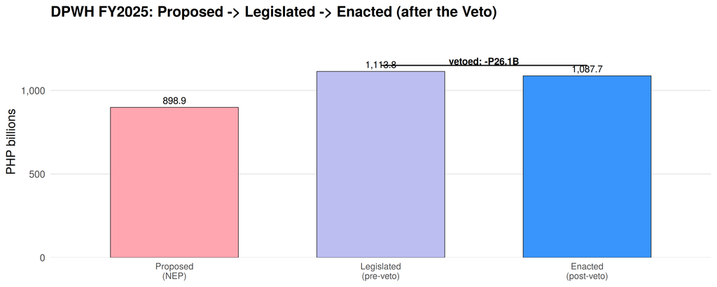

The vetoed amounts fell on three programs, and, as in 2019, almost entirely on centrally-held appropriations:

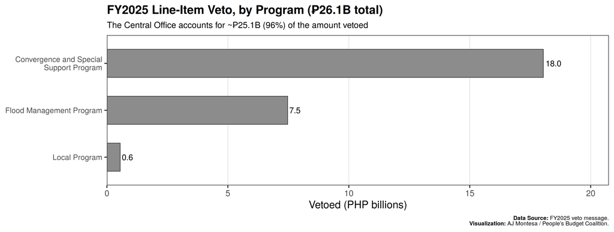

As in 2019, the veto was overwhelmingly a **Central Office** event - about **₱25.1B (96%)** of the ₱26.1B struck was drawn from centrally-held appropriations, with only token amounts removed from named district offices. The recurring story is the same across both years: the largest discretionary build-ups are inserted centrally during deliberations, and it is there that the veto pen, when used, falls.

# 9 The FY 2027 Proposal

FY 2027 is where the history in this report becomes a test. If the patterns above were warning signs visible before the scandal, the question for the budget now before Congress is whether it repeats them or breaks from them. This section draws the FY 2027 figures together in one place: the proposal's overall size, its distribution **by program** and **by district engineering office**, how it compares with the previous year's proposed (**NEP**) and enacted (**GAA**) budgets, and what the House did to it at second reading. The FY 2027 NEP is the live document advocates can still shape. The House figures are a House-stage amount (HB 10858, as approved on second reading), not a final appropriation.

## 9.1 FY 2027 in Context: Comparison with FY 2026

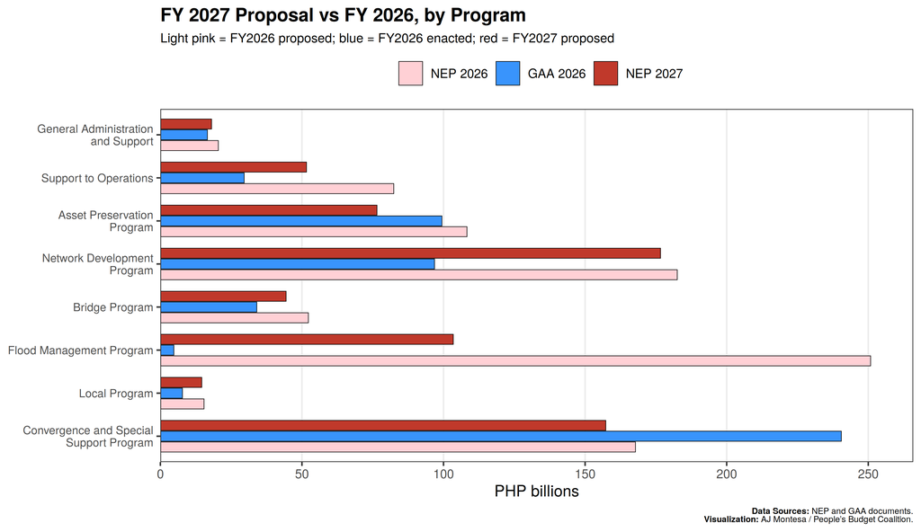

Read program by program, the FY 2027 proposal looks far more like the FY 2026 *proposal* than the FY 2026 *enacted* budget - the Executive is, in effect, re-proposing much of what Congress rearranged on the way to the 2026 GAA:

- **Flood Management**, gutted to just **₱4.8B** in the 2026 GAA, is restored to **₱103.5B** in the FY 2027 proposal (though still below its ₱250.8B FY2026 NEP).
- **Network Development**, which Congress cut to **₱96.8B** on enactment, returns to **₱176.6B** - close to its original FY2026 proposal.
- The **Convergence and Special Support Program** - which Congress *inflated* to **₱240.5B** on enactment - is proposed back down at **₱157.3B**, roughly its FY2026 proposed level.

The full comparison, with the proposed change measured against the enacted 2026 budget (the current baseline):

FY 2027 Proposed New Appropriations vs FY 2026, by Program (PHP billions)

| Program | NEP 2026 | GAA 2026 | NEP 2027 | Chg. vs 2026 GAA |
| --- | --- | --- | --- | --- |
| Network Development Program | 182.5 | 96.8 | 176.6 | 79.8 |
| Convergence and Special Support Program | 167.8 | 240.5 | 157.3 | -83.2 |
| Flood Management Program | 250.8 | 4.8 | 103.5 | 98.7 |
| Asset Preservation Program | 108.3 | 99.4 | 76.5 | -22.9 |
| Support to Operations | 82.4 | 29.6 | 51.6 | 22.0 |
| Bridge Program | 52.3 | 34.1 | 44.4 | 10.4 |
| General Administration and Support | 20.5 | 16.6 | 18.1 | 1.5 |
| Local Program | 15.4 | 7.8 | 14.6 | 6.8 |

## 9.2 By Program: Proposed and Enacted Levels

Zooming in on the programs, it helps to see the **overall levels** the Executive proposes and the legislature enacts - the raw distribution of pesos across programs, and where the **FY 2027 proposal** places them relative to the recent past.

At the department level, the FY 2027 NEP proposes **₱642.6B** - a marked step down from the ₱880B proposed for 2026 and the ₱1,087.7B *enacted* for 2025 (the 2025 figure is the post-veto total; see the veto section). The proposed-versus-enacted totals over the full window make the swings plain:

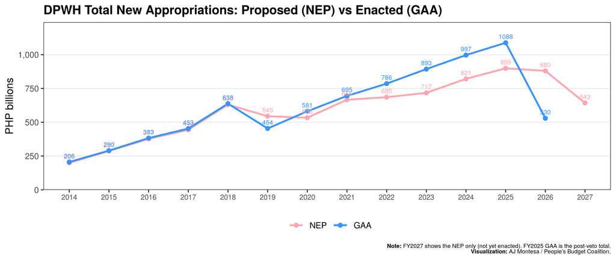

The enacted budget ran *above* the proposal nearly every year from 2014 to 2025, a legislature steadily adding to the President's plan. The exception is FY2019, when the presidential veto pulled the enacted total below the proposal. FY2026 then fell far *below* the proposal (the ₱246B flood-control cut), and the FY2027 proposal resets the level near ₱643B.

**How is the FY 2027 proposal distributed across programs?** Two programs account for more than half of it: Network Development (₱176.6B, 27%) and the Convergence and Special Support Program (₱157.3B, 25%) - the latter historically the *discretionary* program that Congress inflated through realignments, now proposed at a high level in the Executive's own document.

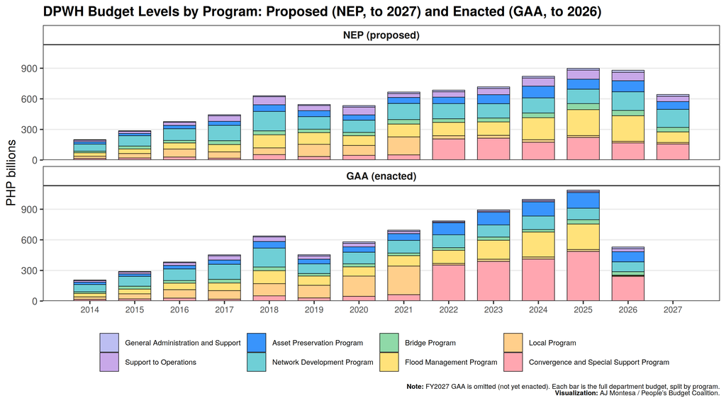

FY 2027 Proposed New Appropriations by Program (NEP)

| Program | NEP 2027 (PHP B) | Share of proposal |
| --- | --- | --- |
| Network Development Program | 176.6 | 27.5% |
| Convergence and Special Support Program | 157.3 | 24.5% |
| Flood Management Program | 103.5 | 16.1% |
| Asset Preservation Program | 76.5 | 11.9% |
| Support to Operations | 51.6 | 8.0% |
| Bridge Program | 44.4 | 6.9% |
| General Administration and Support | 18.1 | 2.8% |
| Local Program | 14.6 | 2.3% |

## 9.3 Inside the Proposal: The Biggest Line Items

Applying the same granular lens to the **FY 2027 proposal** shows what the Executive is prioritising *within* the programs. The largest proposed items are a telling mix of the national works Congress usually trims and the district-oriented items it usually adds.

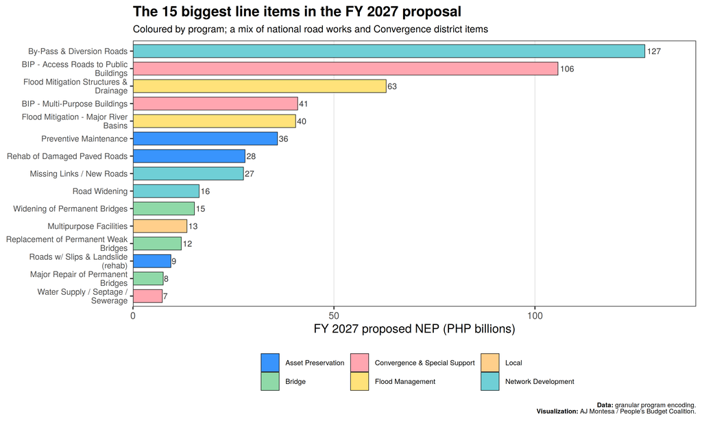

## 9.4 By District Engineering Office: The Proposed Distribution

Having seen how Congress has historically built up district budgets, the same geographic lens applies to the **FY 2027 proposal**. Its starting distribution across operating units is strikingly centralized, a reminder that the district-level build-up documented above happens *after* the proposal, not in it.

Of the ₱642.6B proposed for FY 2027, **₱510.0B (79%) sits in the Central Office** and only **₱129.7B (20%) is distributed across the 198 district engineering offices** (the small remainder is in regional and other units). That 79/20 split is the raw material Congress works on: the district-level build-up that defines DPWH's budget politics happens *later*, in the move from proposal to enacted law.

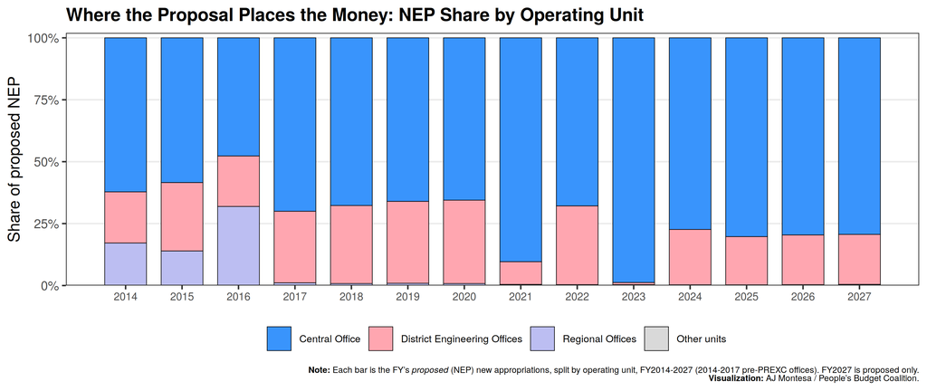

**Which districts fare best in the proposal?** Even within the 20% that is pre-allocated to named districts, the FY2027 NEP is concentrated: the top office is proposed ₱3.5B while the median district gets a fraction of that.

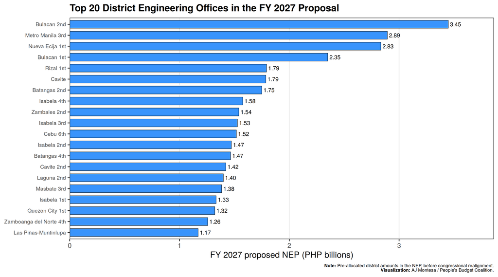

The offices proposed the most in FY2027 - Bulacan 2nd (₱3.5B), Metro Manila 3rd (₱2.9B), Nueva Ecija 1st (₱2.8B) - are a mix of high-population and infrastructure-heavy districts. But the more important point for scrutiny is the gap between this proposed geography and the *enacted* one: as the realignment analysis above shows, Congress adds heavily to district offices during deliberations, so the enacted distribution of DPWH money will look very different from this proposal.

## 9.5 From Proposal to House Bill: The FY 2027 District Shift

The FY 2027 budget is still moving through Congress. The House has approved its version on second reading (HB 10858, in its third-reading print), which gives the NEP a House-stage amount to measure against rather than an enacted GAA; every FY 2027 figure here is that House-stage amount, not a final appropriation. At that stage the House made the same move the enacted budgets above make every year, and made it sharply. It cut the DPWH Central Office by **₱42.4 billion** (₱510.0B to ₱467.6B) and added **₱53.9 billion** to the district engineering offices (₱129.7B to ₱183.6B), lifting the district share of the department from **20% to 28%** in a single chamber. The department total rose only about ₱11B, so most of the district gain is money shifted out of the Central Office rather than new appropriation. In the net-versus-gross terms above, this is a ₱54B net that sits close to a ₱56B gross: the House pushed in one direction, raising 158 of the 198 district offices and trimming only 20.

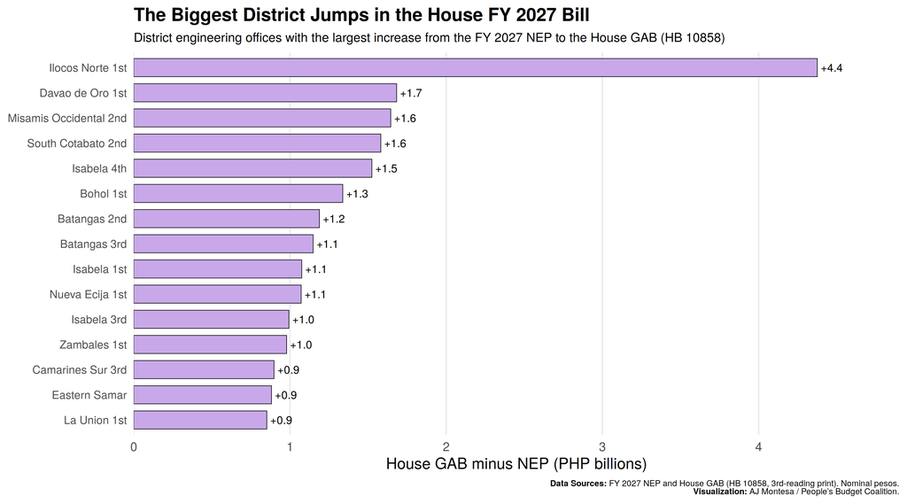

The largest single jump is **Ilocos Norte's 1st district**, the President's home province, which the House raised from ₱0.41B to ₱4.79B, nearly twelve times the proposal. Davao de Oro, Misamis Occidental, South Cotabato, and Isabela's 4th district part of the Speaker's home province, follow. Whether increases like these track construction need or the political geography of the districts - the home provinces of presidents, Speakers, and appropriations chairs, examined in the political-geography section above - is the question they raise most sharply.

# 10 DPWH and the Unprogrammed Appropriations

The **Unprogrammed Appropriations (UA)** is a standby fund that may only be released when revenue collections exceed targets or new financing is secured. Because releases happen *outside* the regular program structure, they are harder to track - and the DPWH's draw on the UA has become a focus of scrutiny, as a number of flood-control projects later flagged as questionable were reportedly financed through this route. The table records **allotments released** (the spending authority granted) and **obligations** (amounts actually committed); obligation data before 2013 could not be sourced, and FY2015-2017 carried no UA releases to the DPWH at all.

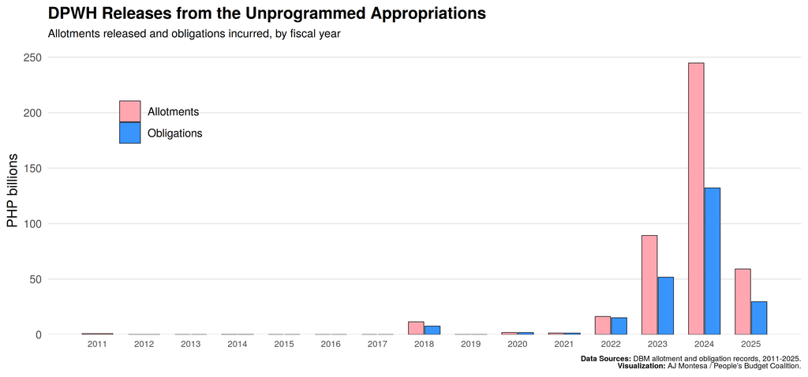

After a decade of negligible draws, UA releases to the DPWH surged from **₱16B in 2022 to ₱89B in 2023 and ₱245B in 2024** - the latter alone roughly a quarter of the department's entire regular budget that year. Yet a large share of these allotments went unobligated (about **54% utilised in 2024**, **50% in 2025**), which, alongside the project-level findings reported elsewhere, is exactly the kind of pattern that merits questioning at the hearings.

DPWH releases from the Unprogrammed Appropriations, PHP billions

| FY | Allotments (B) | Obligations (B) | Utilization |
| --- | --- | --- | --- |
| 2011 | 0.81 | – | – |
| 2012 | 0.02 | – | – |
| 2013 | 0.00 | 0.00 | – |
| 2014 | 0.04 | 0.04 | 99% |
| 2015 | 0.00 | 0.00 | – |
| 2016 | 0.00 | 0.00 | – |
| 2017 | 0.00 | 0.00 | – |
| 2018 | 11.45 | 7.63 | 67% |
| 2019 | 0.01 | 0.01 | 100% |
| 2020 | 1.84 | 1.80 | 97% |
| 2021 | 1.36 | 1.31 | 96% |
| 2022 | 16.26 | 15.11 | 93% |
| 2023 | 89.33 | 51.72 | 58% |
| 2024 | 244.74 | 132.19 | 54% |
| 2025 | 59.08 | 29.62 | 50% |

# 11 Notes

**On coverage.** The Section 3 series is intentionally left with gaps where the physical documents have not yet been encoded; points mark observed years. The by-operating-unit data now runs from the FY2014 budget through FY2026, so the department-wide comparisons span the 16th through 20th Congresses and seven House Speakers (see the Speaker table in the operating-unit section). The district-office deep-dives center on the Duterte and Marcos administrations (FY2017 onward - ten budgets, 2019 included), though the realignments-by-Congress chart reaches back to the 16th Congress (the three Aquino-era budgets) for context. The FY2019 figures use the enacted, post-veto GAA; the ₱95.4B line-item veto that year is isolated in its own chart and section.

**On the 2019 GAA.** The GAA figures throughout are the **enacted, post-veto** levels (they reconcile to the Office-of-the-Secretary totals in Section 3). "Legislated (pre-veto)" reconstructs what Congress passed by adding the vetoed amounts back to the enacted GAA. Because of this, every 2019 realignment figure in this document reflects the *combined* effect of Congress's reallocation and the President's veto, not Congress alone; the veto section, the Central-vs-District veto chart, and the grey segments in the realignments-by-Congress chart isolate the veto and recover Congress's pre-veto intent.

**On the Unprogrammed Appropriations.** UA obligation data before 2013 could not be sourced; FY2015-2017 had no UA releases to the DPWH. These realignments are simply the arithmetic NEP-to-GAA difference and are not, on their own, evidence of irregularity.